# Omics_PEC2

Judith Guitart

1/6/2020

# Preparación de los datos

Primeramente se leen los archivos ‘targets.csv’ y ‘counts.csv’ que se encuentran en la carpeta ‘Datos’ dentro de la carpeta ‘PEC2’ de la asignatura, establecida como el directorio principal de este análisis.

```r
targets <- read.csv("./Datos/targets.csv", header = TRUE, sep = ",", row.names=1)
head(targets)
```

```
##           SRA_Sample              Sample_Name Grupo_analisis body_site
## SRX567480  SRS626942 GTEX-111CU-0226-SM-5GZXC              1   Thyroid
## SRX615964  SRS644174 GTEX-111FC-1026-SM-5GZX1              1   Thyroid
## SRX563960  SRS625636 GTEX-111VG-0526-SM-5N9BW              3   Thyroid
## SRX564185  SRS625665 GTEX-111YS-0726-SM-5GZY8              1   Thyroid
## SRX559141  SRS624025 GTEX-1122O-0226-SM-5N9DA              1   Thyroid
## SRX561718  SRS625313 GTEX-1128S-0126-SM-5H12S              1   Thyroid
##                  molecular_data_type    sex Group ShortName
## SRX567480 Allele-Specific Expression   male   NIT 111CU_NIT
## SRX615964              RNA Seq (NGS)   male   NIT 111FC_NIT
## SRX563960              RNA Seq (NGS)   male   ELI 111VG_ELI
## SRX564185 Allele-Specific Expression   male   NIT 111YS_NIT
## SRX559141              RNA Seq (NGS) female   NIT 1122O_NIT
## SRX561718 Allele-Specific Expression female   NIT 1128S_NIT
```

```r
counts <- read.csv("./Datos/counts.csv", header = TRUE, sep = ";", row.names = 1)
```

A continuación, se extraen 10 muestras de cada uno de los grupos (NIT, SFI y ELI) de manera aleatoria del archivo ‘targets.csv’ mediante el paquete dplyr:

```r
library(dplyr)
set.seed(3333)
targets.pec <- targets %>% group_by(Group) %>% sample_n(10) %>% arrange(Grupo_analisis)
str(targets.pec)
```

```
## tibble [30 x 8] (S3: grouped_df/tbl_df/tbl/data.frame)
##  $ SRA_Sample         : chr [1:30] "SRS629372" "SRS629803" "SRS627199" "SRS389744" ...
##  $ Sample_Name        : chr [1:30] "GTEX-11ZTT-1026-SM-5EQKF" "GTEX-11GSO-0626-SM-5A5LW" "GTEX-Y5V5-0326-SM-5RQJG" "GTEX-QEL4-0726-SM-3GIJ5" ...
##  $ Grupo_analisis     : int [1:30] 1 1 1 1 1 1 1 1 1 1 ...
##  $ body_site          : chr [1:30] "Thyroid" "Thyroid" "Thyroid" "Thyroid" ...
##  $ molecular_data_type: chr [1:30] "Allele-Specific Expression" "RNA Seq (NGS)" "RNA Seq (NGS)" "Allele-Specific Expression" ...
##  $ sex                : chr [1:30] "female" "male" "female" "male" ...
##  $ Group              : chr [1:30] "NIT" "NIT" "NIT" "NIT" ...
##  $ ShortName          : chr [1:30] "11ZTT_NIT" "11GSO_NIT" "Y5V5-_NIT" "QEL4-_NIT" ...
##  - attr(*, "groups")= tibble [3 x 2] (S3: tbl_df/tbl/data.frame)
##   ..$ Group: chr [1:3] "ELI" "NIT" "SFI"
##   ..$ .rows: list<int> [1:3]
##   .. ..$ : int [1:10] 21 22 23 24 25 26 27 28 29 30
##   .. ..$ : int [1:10] 1 2 3 4 5 6 7 8 9 10
##   .. ..$ : int [1:10] 11 12 13 14 15 16 17 18 19 20
##   .. ..@ ptype: int(0)
##   ..- attr(*, ".drop")= logi TRUE
```

Se observa que el output es el deseado.

A continuación, se quiere subsetear estas muestras escogidas en las columnas del archivo ‘counts.csv’ para obtener la información adecuada de cada una de las muestras.

Para ello, es necesario que los nombres de la columna ‘Sample_Name’ coincidan con los nombres de cada una de las columnas del archivo ‘counts.csv’. Para ello, es posible utilizar la función gsub para sustituir el carácter . por el carácter -.

```r
names(counts) <- gsub(x=names(counts), pattern = "\\.", replacement = "-")
```

Para obtener el archivo ‘counts.pec’ con los datos de ‘counts’ de las muestras seleccionadas en el archivo ‘targets.pec’, se usa la función select del paquete dyplr:

```r
counts.pec <- counts %>% select(one_of(as.character(targets.pec$Sample_Name)))
str(counts.pec)
```

```
## 'data.frame':    56202 obs. of  30 variables:
##  $ GTEX-11ZTT-1026-SM-5EQKF: int  3 580 0 1 1 0 2 3 13 879 ...
##  $ GTEX-11GSO-0626-SM-5A5LW: int  0 544 0 3 0 0 2 4 5 1129 ...
##  $ GTEX-Y5V5-0326-SM-5RQJG : int  1 424 0 2 1 0 0 10 5 241 ...
##  $ GTEX-QEL4-0726-SM-3GIJ5 : int  4 511 2 2 4 1 0 5 50 477 ...
##  $ GTEX-RU1J-0226-SM-2TF5Y : int  4 415 1 3 1 2 1 1 161 262 ...
##  $ GTEX-111CU-0226-SM-5GZXC: int  7 401 4 2 0 0 0 6 16 744 ...
##  $ GTEX-XUW1-1026-SM-4BONY : int  2 688 1 0 0 0 0 6 17 868 ...
##  $ GTEX-X4XY-0826-SM-4E3JM : int  1 1071 1 3 0 0 4 1 23 619 ...
##  $ GTEX-133LE-0326-SM-5P9G4: int  4 1175 2 3 2 0 4 4 37 2739 ...
##  $ GTEX-Y111-1926-SM-4SOIS : int  2 810 0 2 0 1 1 6 10 993 ...
##  $ GTEX-13NZ8-0226-SM-5J2OK: int  1 1164 2 2 2 0 0 19 5 181 ...
##  $ GTEX-117YW-0126-SM-5EGGN: int  1 483 0 0 0 0 0 0 10 171 ...
##  $ GTEX-13FH7-0126-SM-5KLZ1: int  5 576 4 3 0 1 2 4 26 772 ...
##  $ GTEX-Q2AH-0726-SM-2I3EA : int  1 874 8 2 0 1 3 4 31 1086 ...
```

[output cut: 16 more lines]

Esta matriz de contaje contiene en cada fila un gen con el código Ensembl y cada una de las librerias RNA secuenciadas en las columnas con los respectivos valores asignados.

Es posible comprobar que las filas del archivo ‘targets.pec’ coincida con las columnas del archivo ‘counts.pec’:

```r
all(rownames(targets.pec$Sample_Name) == colnames(counts.pec))
```

```
## [1] TRUE
```

```r
write.csv(targets.pec, "./Datos/targets.pec.csv")
write.csv(counts.pec, "./Datos/counts.pec.csv")
```

A continuación, se crea la matriz del objeto DESeqDataSet que consta de los contajes (counts.pec) y la tabla de información de las muestas (targets.pec), mediante funciones del paquete *DESeq2*. La fórmula de diseño define qué columnas de la tabla de información de las muestras (targets.pec) especifica el diseño experimental y cómo estos factores deben usarse en el análisis. Como queremos determinar el efecto de los distintos grupos NIT, SFI y ELI, la fórmula de diseño será ~ Group.

```r
if (!requireNamespace("BiocManager", quietly = TRUE))
    install.packages("BiocManager")
BiocManager::install("DESeq2")
library("DESeq2")
```

DESeq2 offers transformations for count data that stabilize the variance across the mean: the regularized logarithm (rlog) and the variance stabilizing transformation (VST). These have slightly different implementations, discussed a bit in the DESeq2 paper and in the very extensive web tutorial, but a similar goal of stablizing the variance across the range of values. Both produce log2-like values for high counts. Here we will use the regularized log transformation implemented with the rlog function.

```r
ddsM <- DESeqDataSetFromMatrix(countData = counts.pec, colData = targets.pec, design = ~Group)
ddsM
```

```
## class: DESeqDataSet
## dim: 56202 30
## metadata(1): version
## assays(1): counts
## rownames(56202): ENSG00000223972.4 ENSG00000227232.4 ...
##   ENSG00000210195.2 ENSG00000210196.2
## rowData names(0):
## colnames(30): GTEX-11ZTT-1026-SM-5EQKF GTEX-11GSO-0626-SM-5A5LW ...
##   GTEX-YJ89-0726-SM-5P9F7 GTEX-13NZ9-1126-SM-5MR37
## colData names(8): SRA_Sample Sample_Name ... Group ShortName
```

# Preprocesado de los datos: filtraje y normalización

Con el objetivo de visualizar relaciones entre las muestras, primeramente se van a realizar transformaciones en los contajes y seguidamente se van a realizar test estadísticos sobre los mismos.

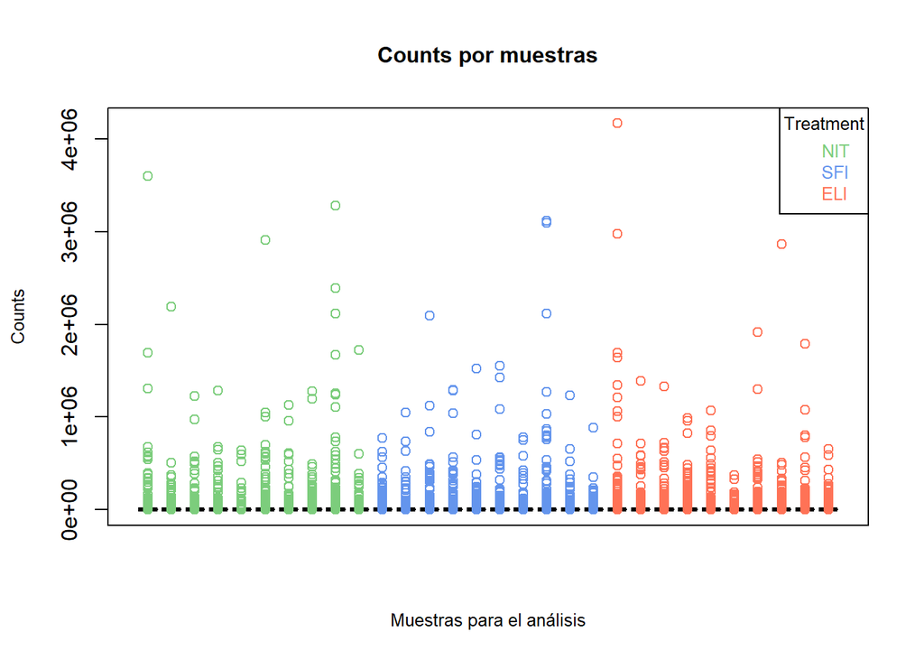

```r
boxplot(counts.pec, names = c(rep(" ",30)), outcol = c(rep("palegreen3",10),rep("cornflowerblue",10),rep("coral1",10)), xaxt="n", main = "Counts por muestras", xlab = "Muestras para el análisis", ylab = "Counts", cex.lab = 0.8, cex.main=1)
legend("topright",legend=c("NIT","SFI","ELI"), text.col=c("palegreen3","cornflowerblue","coral1"), cex=0.8, title = "Treatment", title.col = "black")
```

## Pre-filtrado de los datos

Este paso consiste en eliminar esas líneas que menos de 10 reads con el objetivo de reducir las dimensiones del objeto de datos y así incrementar la velocidad de las funciones, ya que no aportan información al análisis. (que seria un cpm de 0.5)

Así, se observa que el objeto inicial contiene 56202 líneas.

```r
nrow(ddsM)
```

```
## [1] 56202
```

```r
dds <- ddsM[rowSums(counts(ddsM)) >= 10, ]
nrow(dds)
```

```
## [1] 35894
```

## Transformación para varianza estable y rlog

Muchos métodos estadísticos requieren que la varianza sea homogénea entre las muestras, es decir, requieren homocedasticidad. El paquete *DESeq2* ofrece dos transformaciones para contajes de RNA-seq para estabilizar la varianza: la función *Vst* y la función *rlog*.

Se realiza primeramente una transformación con la función *vst*, ya que nuestros datos contienen 30 muestras, con el atributo blind en *FALSE*, pues en esta primera transformación no quieren establecerse diferencias entre los grupos.

```r
vsd <- vst(dds, blind=FALSE)
```

A ctontinuación se realiza la otra función de transformación:

```r
rld <- rlog(dds, blind=FALSE)
```

```
## rlog() may take a few minutes with 30 or more samples,
## vst() is a much faster transformation
```

Para mostrar el efecto de la transformación se muestran en los siguientes plots:

```r
BiocManager::install("hexbin")
```

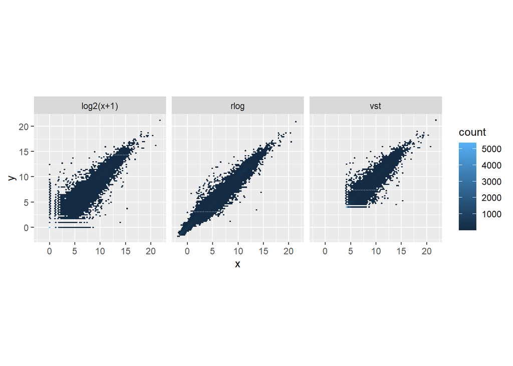

```r
library("ggplot2")
library("hexbin")
ddsN <- estimateSizeFactors(dds)
df <- bind_rows(
  as_data_frame(log2(counts(ddsN, normalized=TRUE)[, 1:2]+1)) %>% mutate(transformation = "log2(x+1)"),
  as_data_frame(assay(vsd)[, 1:2]) %>% mutate(transformation = "vst"), as_data_frame(assay(rld)[, 1:2]) %>% mutate(transformation = "rlog")
)
colnames(df)[1:2] <- c("x","y")
ggplot(df, aes(x = x, y = y)) + geom_hex(bins = 80) + coord_fixed() + facet_grid( . ~transformation)
```

A la izquierda se observan los contajes normalizados transformados log2, con la transformación rlog en el medio y a la derecha se encuentran los datos transformados con VST. Se observa como las transformaciones vst y rlog muestran diferencias por los genes con muy bajos contajes, ya que estos datos dan poca información sobre expresión diferencial.

The trend typically captures high dispersions for low counts, and therefore these genes exhibit higher shrinkage from the rlog.

## Normalization:

```r
BiocManager::install("edgeR")
library("edgeR")
```

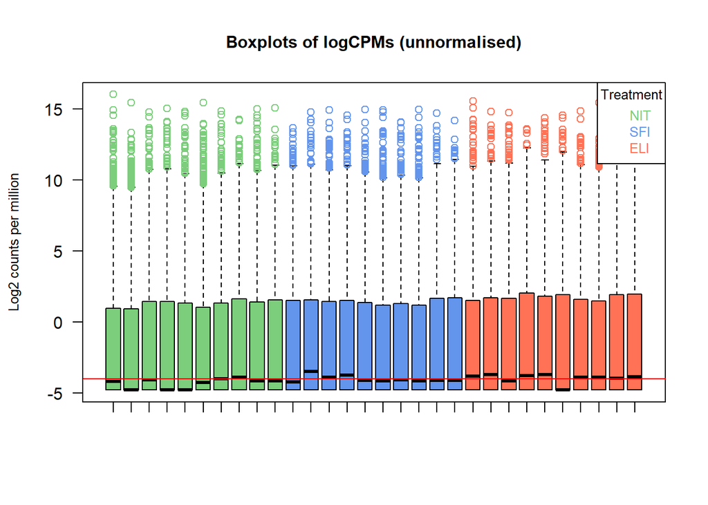

```r
logcounts <- cpm(counts.pec, log=TRUE)
boxplot(logcounts, names = c(rep(" ",30)), col = c(rep("palegreen3",10),rep("cornflowerblue",10),rep("coral1",10)), outcol = c(rep("palegreen3",10),rep("cornflowerblue",10),rep("coral1",10)), ylab = "Log2 counts per million", las=2, cex.lab = 0.8)
abline(h=median(logcounts), col="red")
title("Boxplots of logCPMs (unnormalised)", cex.main = 1)
legend("topright",legend=c("NIT","SFI","ELI"), text.col=c("palegreen3","cornflowerblue","coral1"), cex=0.8, title = "Treatment", title.col = "black")
```

```r
ddsN = estimateSizeFactors(dds)
```

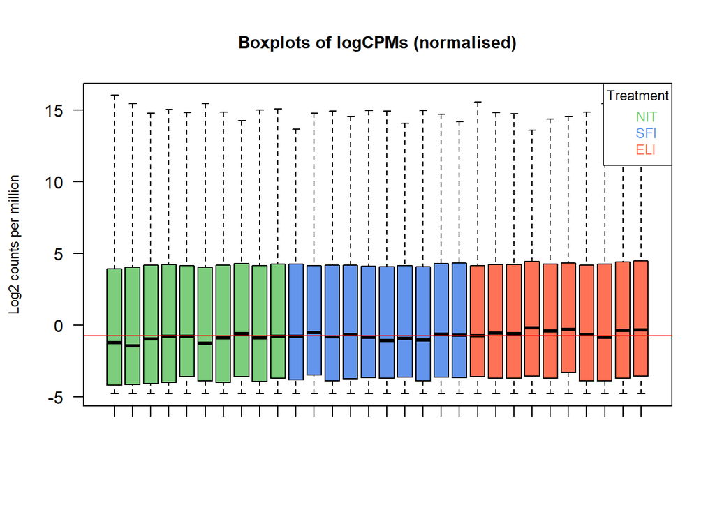

```r
normcounts <- cpm(ddsN, log = TRUE)
boxplot(normcounts, names = c(rep(" ",30)), col = c(rep("palegreen3",10),rep("cornflowerblue",10),rep("coral1",10)), ylab = "Log2 counts per million", las=2, cex.lab = 0.8)
abline(h=median(normcounts), col="red")
title("Boxplots of logCPMs (normalised)", cex.main = 1)
legend("topright",legend=c("NIT","SFI","ELI"), text.col=c("palegreen3","cornflowerblue","coral1"), cex=0.8, title = "Treatment", title.col = "black")
```

Els valors de mediana son mas parecidos ahora.

# Visualización de los datos

## Distancias entre las muestras

```r
sampleDists <- dist(t(assay(vsd)))
```

Ahora visualizamos estas distancias en un mapa de calor con la función pheatmap añadiendo las distancias entre las muestras como argumento para generar clusters entre las muestras.

```r
BiocManager::install("pheatmap")
BiocManager::install("RColorBrewer")
library("pheatmap")
library("RColorBrewer")
sampleDistMatrix <- as.matrix(sampleDists)
rownames(sampleDistMatrix) <- paste(vsd$Group, sep = " - ")
colnames(sampleDistMatrix) <- NULL
colors <- colorRampPalette(rev(brewer.pal(30, "Blues")) )(255)
pdf("pheatmap1.pdf")
pheatmap1 <- pheatmap(sampleDistMatrix, clustering_distance_rows  = sampleDists, clustering_distance_cols = sampleDists, col = colors)
dev.off()
```

```r
BiocManager::install("PoiClaClu")
```

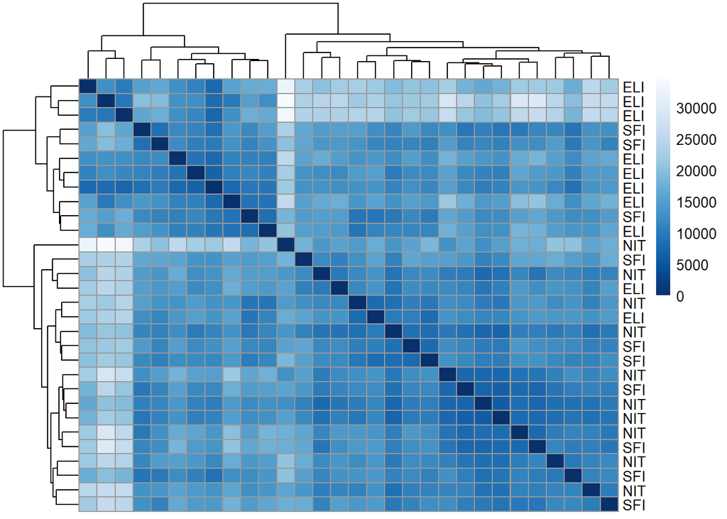

```r
library("PoiClaClu")
poisd <- PoissonDistance(t(counts(dds)))
samplePoisDistMatrix <- as.matrix( poisd$dd )
rownames(samplePoisDistMatrix) <- paste( dds$Group, sep=" - " )
colnames(samplePoisDistMatrix) <- NULL
pheatmap(samplePoisDistMatrix,
         clustering_distance_rows = poisd$dd,
         clustering_distance_cols = poisd$dd,
         col = colors)
```

## PCA Plot

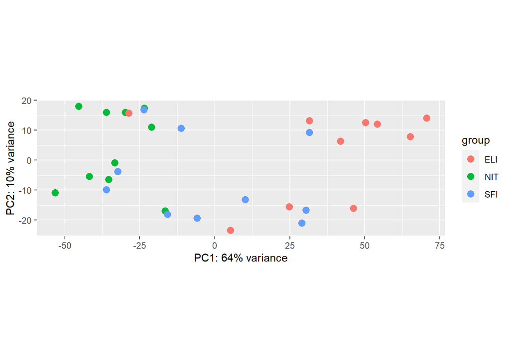

```r
plotPCA(vsd, intgroup = c("Group"))
```

Se observa una separación entre los distintos grupos, aunque también hay algunas muestras que se disipan con otros grupos.

(afegir glm-pca?)

## MDS plot (Multidimensional scaling plots)

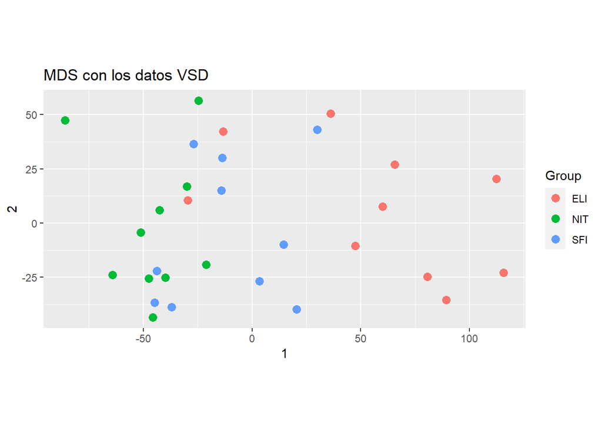

```r
mds <- as.data.frame(colData(vsd)) %>% cbind(cmdscale(sampleDistMatrix))
ggplot(mds, aes(x = `1`, y = `2`, color = Group)) + geom_point(size=3) + coord_fixed() + ggtitle("MDS con los datos VSD")
```

```r
pdf("PCAandMDS.pdf")
par(mfrow=c(1,2))
plotPCA(vsd, intgroup = c("Group"))
mds <- as.data.frame(colData(vsd)) %>% cbind(cmdscale(sampleDistMatrix))
ggplot(mds, aes(x = `1`, y = `2`, color = Group)) + geom_point(size=3) + coord_fixed() + ggtitle("MDS con los datos VSD")
dev.off()
```

# Análisis de expresión diferencial entre grupos

```r
dds <- DESeq(dds, parallel = TRUE)
```

```
## -- replacing outliers and refitting for 282 genes
## -- DESeq argument 'minReplicatesForReplace' = 7
## -- original counts are preserved in counts(dds)
```

La función DESeq lleva a cabo las siguientes tres funciones en los datos crudos: estimateSizeFactors(dds), estimateDispersions(dds) y nbinomWaldTest(dds). The results function of the DESeq2 package performs independent filtering by default using the mean of normalized counts as a filter statistic. A threshold on the filter statistic is found which optimizes the number of adjusted p values lower than a [specified] significance level”.

## NIT vs SFI

```r
res_NITvsSFI <- results(dds, contrast=c("Group","NIT","SFI"), alpha=0.05)
head(res_NITvsSFI)
```

```
## log2 fold change (MLE): Group NIT vs SFI
## Wald test p-value: Group NIT vs SFI
## DataFrame with 6 rows and 6 columns
##                     baseMean log2FoldChange     lfcSE      stat    pvalue
##                    <numeric>      <numeric> <numeric> <numeric> <numeric>
## ENSG00000223972.4   2.841267       0.217934  0.659522  0.330442  0.741066
## ENSG00000227232.4 711.933057      -0.110665  0.235843 -0.469231  0.638905
## ENSG00000243485.2   1.333301      -0.595119  0.816481 -0.728883  0.466073
## ENSG00000237613.2   1.653664       0.860066  0.713099  1.206097  0.227780
## ENSG00000268020.2   0.786348       1.362206  1.281722  1.062794  0.287876
## ENSG00000240361.1   0.706012       0.168742  1.267970  0.133080  0.894130
##                        padj
##                   <numeric>
## ENSG00000223972.4  0.963096
## ENSG00000227232.4  0.947186
## ENSG00000243485.2        NA
## ENSG00000237613.2        NA
## ENSG00000268020.2        NA
## ENSG00000240361.1        NA
```

```r
summary(res_NITvsSFI)
```

```
##
## out of 35890 with nonzero total read count
## adjusted p-value < 0.05
## LFC > 0 (up)       : 16, 0.045%
## LFC < 0 (down)     : 285, 0.79%
## outliers [1]       : 0, 0%
## low counts [2]     : 7658, 21%
## (mean count < 2)
## [1] see 'cooksCutoff' argument of ?results
## [2] see 'independentFiltering' argument of ?results
```

```r
resSig_NITvsSFI <- subset(res_NITvsSFI, padj <= 0.05)
head(resSig_NITvsSFI[ order(resSig_NITvsSFI$log2FoldChange), ])
```

```
## log2 fold change (MLE): Group NIT vs SFI
## Wald test p-value: Group NIT vs SFI
## DataFrame with 6 rows and 6 columns
##                    baseMean log2FoldChange     lfcSE      stat      pvalue
##                   <numeric>      <numeric> <numeric> <numeric>   <numeric>
## ENSG00000211930.1   18.1191       -8.32028   1.59002  -5.23283 1.66937e-07
## ENSG00000211670.2  228.1669       -8.24635   1.14141  -7.22468 5.02276e-13
## ENSG00000223648.2   80.7691       -7.91951   1.27513  -6.21076 5.27287e-10
## ENSG00000211951.2  224.7878       -7.90541   1.19675  -6.60571 3.95627e-11
## ENSG00000254395.1   73.6506       -7.86433   1.12051  -7.01852 2.24223e-12
## ENSG00000224373.2 2417.2338       -7.84254   1.14513  -6.84861 7.45689e-12
##                          padj
##                     <numeric>
## ENSG00000211930.1 5.17981e-05
## ENSG00000211670.2 1.77278e-09
## ENSG00000223648.2 3.16776e-07
## ENSG00000211951.2 3.86031e-08
## ENSG00000254395.1 5.75560e-09
## ENSG00000224373.2 1.23855e-08
```

```r
head(resSig_NITvsSFI[ order(resSig_NITvsSFI$log2FoldChange, decreasing = TRUE), ])
```

```
## log2 fold change (MLE): Group NIT vs SFI
## Wald test p-value: Group NIT vs SFI
## DataFrame with 6 rows and 6 columns
##                    baseMean log2FoldChange     lfcSE      stat      pvalue
##                   <numeric>      <numeric> <numeric> <numeric>   <numeric>
## ENSG00000110680.8 162.54852        4.32314  1.010264   4.27922 1.87548e-05
## ENSG00000163501.6 139.22269        3.77893  0.838182   4.50848 6.52926e-06
## ENSG00000240707.2   3.86898        2.90660  0.788996   3.68393 2.29669e-04
## ENSG00000267131.1   9.88376        2.81455  0.549238   5.12446 2.98394e-07
## ENSG00000247311.2  36.96961        2.38123  0.685129   3.47560 5.09714e-04
## ENSG00000224965.1  42.93248        2.21548  0.620896   3.56820 3.59445e-04
##                          padj
##                     <numeric>
## ENSG00000110680.8 0.003209461
## ENSG00000163501.6 0.001280280
## ENSG00000240707.2 0.026043874
## ENSG00000267131.1 0.000087765
## ENSG00000247311.2 0.048622607
## ENSG00000224965.1 0.037589909
```

```r
library("xlsx")
write.csv(resSig_NITvsSFI, "./Resultados/resSig_NITvsSFI.csv")
write.xlsx(resSig_NITvsSFI, "./Resultados/resSig_NITvsSFI.xlsx")
```

See the help page for results (by typing ?results) for information on how to obtain other contrasts.

Samllest p-value:

```r
idx <- which.min(res_NITvsSFI$pvalue)
counts(dds, normalized = TRUE)[idx,]
```

```
## GTEX-11ZTT-1026-SM-5EQKF GTEX-11GSO-0626-SM-5A5LW  GTEX-Y5V5-0326-SM-5RQJG
##                 0.000000                 4.411896                13.278581
##  GTEX-QEL4-0726-SM-3GIJ5  GTEX-RU1J-0226-SM-2TF5Y GTEX-111CU-0226-SM-5GZXC
##                 0.000000                18.787488                 4.453725
##  GTEX-XUW1-1026-SM-4BONY  GTEX-X4XY-0826-SM-4E3JM GTEX-133LE-0326-SM-5P9G4
##                10.857114                 1.484383                12.618507
##  GTEX-Y111-1926-SM-4SOIS GTEX-13NZ8-0226-SM-5J2OK GTEX-117YW-0126-SM-5EGGN
##                41.774814               123.696373                96.629375
## GTEX-13FH7-0126-SM-5KLZ1  GTEX-Q2AH-0726-SM-2I3EA GTEX-139UW-0126-SM-5KM1B
##              1200.249307              2028.684732              5895.806420
## GTEX-131XG-0226-SM-5IFG1 GTEX-11TUW-0226-SM-5LU8X  GTEX-TKQ1-0126-SM-33HB3
##                80.367347                14.219545               200.234287
## GTEX-12ZZY-0826-SM-5EQMT GTEX-13FXS-0726-SM-5LZXJ  GTEX-TMMY-0826-SM-33HB9
##               235.895462              1079.552450              2439.950733
## GTEX-13QJC-0826-SM-5RQKC  GTEX-ZYY3-1926-SM-5GZXS  GTEX-YFC4-2626-SM-5P9FQ
##               813.871711              2197.297258              3296.855747
## GTEX-11XUK-0226-SM-5EQLW  GTEX-R55G-0726-SM-2TC6J  GTEX-PLZ4-1226-SM-2I5FE
##              1804.397553              1959.534249                31.281933
## GTEX-14ABY-0926-SM-5Q5DY  GTEX-YJ89-0726-SM-5P9F7 GTEX-13NZ9-1126-SM-5MR37
##               346.690970               636.687868              8581.356187
```

## NIT vs ELI

```r
res_NITvsELI <- results(dds, contrast=c("Group","NIT","ELI"), alpha = 0.05)
head(res_NITvsELI)
```

```
## log2 fold change (MLE): Group NIT vs ELI
## Wald test p-value: Group NIT vs ELI
## DataFrame with 6 rows and 6 columns
##                     baseMean log2FoldChange     lfcSE      stat    pvalue
##                    <numeric>      <numeric> <numeric> <numeric> <numeric>
## ENSG00000223972.4   2.841267     0.50302620  0.667534  0.753559 0.4511143
## ENSG00000227232.4 711.933057     0.00935783  0.235921  0.039665 0.9683602
## ENSG00000243485.2   1.333301     0.11587157  0.848794  0.136513 0.8914156
## ENSG00000237613.2   1.653664     1.27912774  0.731939  1.747588 0.0805354
## ENSG00000268020.2   0.786348     0.29647296  1.207803  0.245465 0.8060967
## ENSG00000240361.1   0.706012    -1.25282026  1.173849 -1.067276 0.2858473
##                        padj
##                   <numeric>
## ENSG00000223972.4  0.688095
## ENSG00000227232.4  0.986387
## ENSG00000243485.2  0.954724
## ENSG00000237613.2  0.246874
## ENSG00000268020.2        NA
## ENSG00000240361.1        NA
```

```r
summary(res_NITvsELI)
```

```
##
## out of 35890 with nonzero total read count
## adjusted p-value < 0.05
## LFC > 0 (up)       : 1525, 4.2%
## LFC < 0 (down)     : 3405, 9.5%
## outliers [1]       : 0, 0%
## low counts [2]     : 5571, 16%
## (mean count < 1)
## [1] see 'cooksCutoff' argument of ?results
## [2] see 'independentFiltering' argument of ?results
```

```r
resSig_NITvsELI <- subset(res_NITvsELI, padj <= 0.05)
head(resSig_NITvsELI[ order(resSig_NITvsELI$log2FoldChange), ])
```

```
## log2 fold change (MLE): Group NIT vs ELI
## Wald test p-value: Group NIT vs ELI
## DataFrame with 6 rows and 6 columns
##                    baseMean log2FoldChange     lfcSE      stat      pvalue
##                   <numeric>      <numeric> <numeric> <numeric>   <numeric>
## ENSG00000211650.2  179.4440      -10.33621   1.39169  -7.42709 1.11010e-13
## ENSG00000222037.5  898.6659       -9.49114   1.00183  -9.47382 2.69801e-21
## ENSG00000211640.3 1252.9245       -9.32871   1.18764  -7.85485 4.00248e-15
## ENSG00000211649.2  219.9166       -9.15017   1.21229  -7.54786 4.42478e-14
## ENSG00000211951.2  224.7878       -8.98050   1.19655  -7.50533 6.12721e-14
## ENSG00000234184.1   36.4657       -8.95778   1.40241  -6.38741 1.68715e-10
##                          padj
##                     <numeric>
## ENSG00000211650.2 1.59533e-11
## ENSG00000222037.5 1.02265e-17
## ENSG00000211640.3 9.55647e-13
## ENSG00000211649.2 6.95195e-12
## ENSG00000211951.2 9.24355e-12
## ENSG00000234184.1 1.16008e-08
```

```r
head(resSig_NITvsELI[ order(resSig_NITvsELI$log2FoldChange, decreasing = TRUE), ])
```

```
## log2 fold change (MLE): Group NIT vs ELI
## Wald test p-value: Group NIT vs ELI
## DataFrame with 6 rows and 6 columns
##                    baseMean log2FoldChange     lfcSE      stat      pvalue
##                   <numeric>      <numeric> <numeric> <numeric>   <numeric>
## ENSG00000215323.4   4.69040        5.24499  1.919956   2.73183 6.29842e-03
## ENSG00000110680.8 162.54852        4.15049  1.009889   4.10984 3.95928e-05
## ENSG00000079689.9  79.87186        3.92513  0.969911   4.04689 5.19020e-05
## ENSG00000213215.1   1.74278        3.78770  1.123820   3.37038 7.50647e-04
## ENSG00000163501.6 139.22269        3.64375  0.837913   4.34860 1.37007e-05
## ENSG00000210184.1   1.89542        3.61009  1.247249   2.89444 3.79838e-03
##                          padj
##                     <numeric>
## ENSG00000215323.4 0.041143229
## ENSG00000110680.8 0.000711661
## ENSG00000079689.9 0.000894726
## ENSG00000213215.1 0.007919881
## ENSG00000163501.6 0.000282809
## ENSG00000210184.1 0.028257651
```

```r
write.xlsx(resSig_NITvsELI, "./Resultados/resSig_NITvsELI.xlsx")
```

## SFI vs ELI

```r
res_SFIvsELI <- results(dds, contrast=c("Group","SFI","ELI"), alpha = 0.05)
head(res_SFIvsELI)
```

```
## log2 fold change (MLE): Group SFI vs ELI
## Wald test p-value: Group SFI vs ELI
## DataFrame with 6 rows and 6 columns
##                     baseMean log2FoldChange     lfcSE      stat    pvalue
##                    <numeric>      <numeric> <numeric> <numeric> <numeric>
## ENSG00000223972.4   2.841267       0.285092  0.670074  0.425464  0.670498
## ENSG00000227232.4 711.933057       0.120023  0.235779  0.509047  0.610719
## ENSG00000243485.2   1.333301       0.710990  0.801901  0.886631  0.375278
## ENSG00000237613.2   1.653664       0.419062  0.774573  0.541023  0.588492
## ENSG00000268020.2   0.786348      -1.065733  1.280113 -0.832530  0.405110
## ENSG00000240361.1   0.706012      -1.421562  1.180453 -1.204251  0.228493
##                        padj
##                   <numeric>
## ENSG00000223972.4  0.850645
## ENSG00000227232.4  0.817353
## ENSG00000243485.2        NA
## ENSG00000237613.2  0.803080
## ENSG00000268020.2        NA
## ENSG00000240361.1        NA
```

```r
summary(res_SFIvsELI)
```

```
##
## out of 35890 with nonzero total read count
## adjusted p-value < 0.05
## LFC > 0 (up)       : 877, 2.4%
## LFC < 0 (down)     : 2317, 6.5%
## outliers [1]       : 0, 0%
## low counts [2]     : 6963, 19%
## (mean count < 2)
## [1] see 'cooksCutoff' argument of ?results
## [2] see 'independentFiltering' argument of ?results
```

```r
resSig_SFIvsELI <- subset(res_SFIvsELI, padj <= 0.05)
head(resSig_SFIvsELI[ order(resSig_SFIvsELI$log2FoldChange), ])
```

```
## log2 fold change (MLE): Group SFI vs ELI
## Wald test p-value: Group SFI vs ELI
## DataFrame with 6 rows and 6 columns
##                     baseMean log2FoldChange     lfcSE      stat      pvalue
##                    <numeric>      <numeric> <numeric> <numeric>   <numeric>
## ENSG00000160505.11  13.50828       -6.36458  1.379363  -4.61414 3.94721e-06
## ENSG00000170054.10  39.54938       -6.01153  1.447246  -4.15377 3.27038e-05
## ENSG00000162897.10   6.85666       -5.59460  1.044443  -5.35654 8.48317e-08
## ENSG00000221971.3    5.46515       -5.34377  0.890166  -6.00311 1.93568e-09
## ENSG00000224610.1    2.13161       -5.08906  1.079234  -4.71544 2.41189e-06
## ENSG00000127074.10  97.23624       -4.90367  0.718360  -6.82620 8.71961e-12
##                           padj
##                      <numeric>
## ENSG00000160505.11 2.52960e-04
## ENSG00000170054.10 1.23358e-03
## ENSG00000162897.10 1.46087e-05
## ENSG00000221971.3  1.13380e-06
## ENSG00000224610.1  1.71025e-04
## ENSG00000127074.10 2.80297e-08
```

```r
head(resSig_SFIvsELI[ order(resSig_SFIvsELI$log2FoldChange, decreasing = TRUE), ])
```

```
## log2 fold change (MLE): Group SFI vs ELI
## Wald test p-value: Group SFI vs ELI
## DataFrame with 6 rows and 6 columns
##                     baseMean log2FoldChange     lfcSE      stat      pvalue
##                    <numeric>      <numeric> <numeric> <numeric>   <numeric>
## ENSG00000250033.1   58.74632        4.29926  1.010507   4.25455 2.09468e-05
## ENSG00000151012.9 2025.87871        4.04723  0.743898   5.44057 5.31092e-08
## ENSG00000079689.9   79.87186        3.97286  0.969739   4.09683 4.18849e-05
## ENSG00000174417.2    8.78770        3.73263  0.988974   3.77425 1.60490e-04
## ENSG00000100604.8   94.12634        3.31623  1.031867   3.21382 1.30982e-03
## ENSG00000178172.2    1.92728        3.30587  1.091908   3.02761 2.46496e-03
##                          padj
##                     <numeric>
## ENSG00000250033.1 0.000879552
## ENSG00000151012.9 0.000010524
## ENSG00000079689.9 0.001461801
## ENSG00000174417.2 0.003975296
## ENSG00000100604.8 0.018179462
## ENSG00000178172.2 0.028514146
```

```r
write.xlsx(resSig_SFIvsELI, "./Resultados/resSig_SFIvsELI.xlsx")
```

# Visualización de patrones de expresión

```r
BiocManager::install("apeglm")
resultsNames(dds)
```

```
## [1] "Intercept"        "Group_NIT_vs_ELI" "Group_SFI_vs_ELI"
```

## MA-Plot

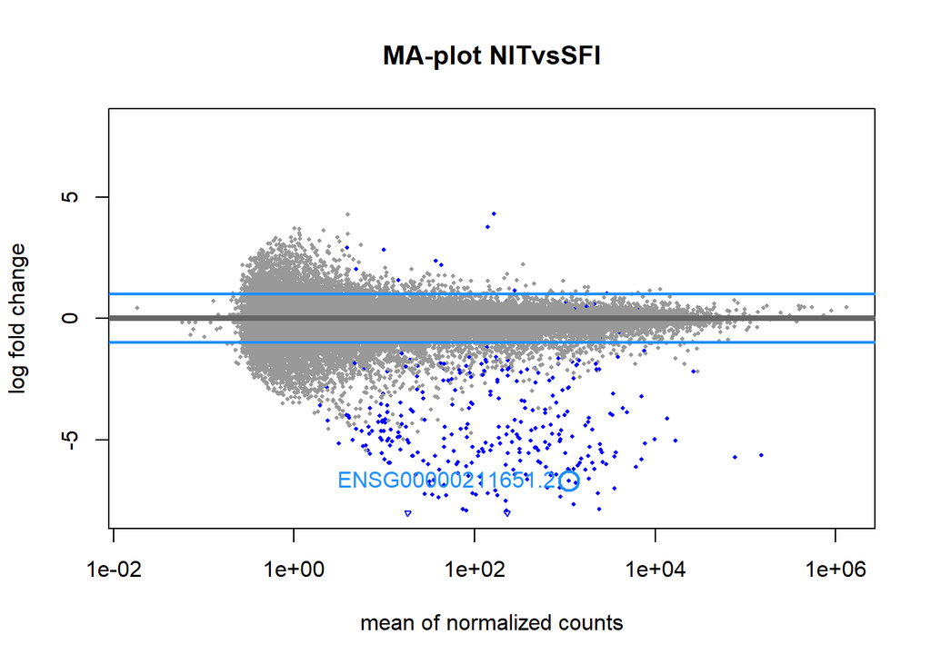

```r
DESeq2::plotMA(res_NITvsSFI, ylim = c(-8,8))
topGene1 <- rownames(res_NITvsSFI)[which.min(res_NITvsSFI$padj)]
with(res_NITvsSFI[topGene1, ], {
  points(baseMean, log2FoldChange, col = "dodgerblue", cex = 2, lwd = 2)
  text(baseMean, log2FoldChange, topGene1, pos = 2, col = "dodgerblue")
})
abline(h=c(-1,1), col="dodgerblue", lwd=2)
title("MA-plot NITvsSFI")
```

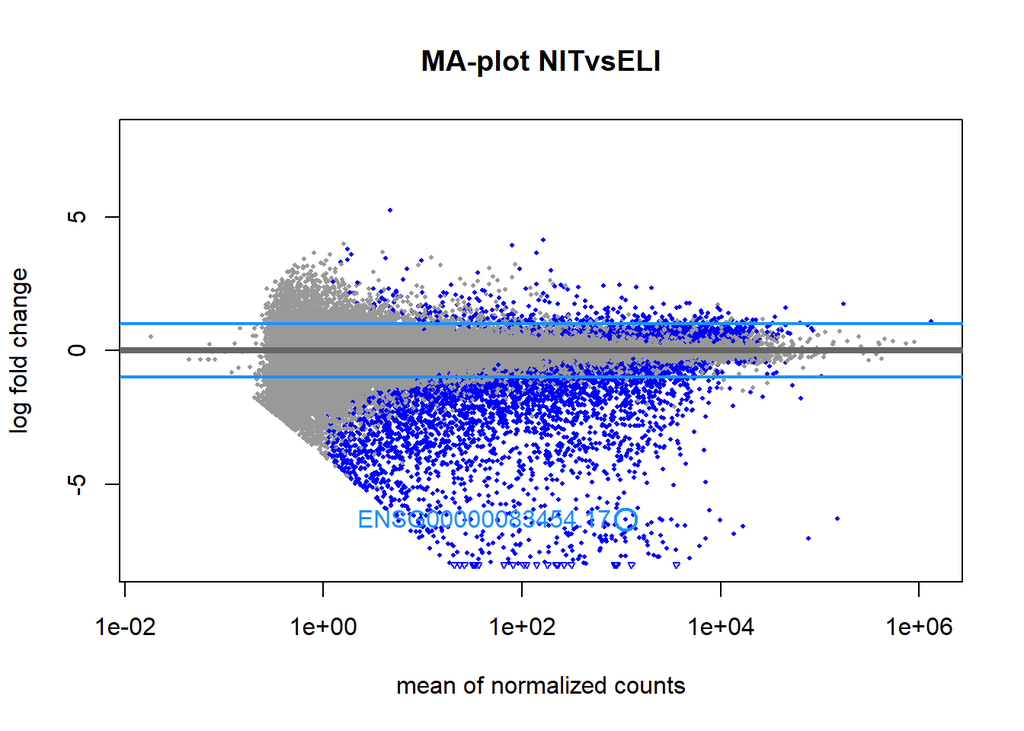

```r
DESeq2::plotMA(res_NITvsELI, ylim = c(-8,8))
topGene2 <- rownames(res_NITvsELI)[which.min(res_NITvsELI$padj)]
with(res_NITvsELI[topGene2, ], {
  points(baseMean, log2FoldChange, col = "dodgerblue", cex = 2, lwd = 2)
  text(baseMean, log2FoldChange, topGene2, pos = 2, col = "dodgerblue")
})
abline(h=c(-1,1), col="dodgerblue", lwd=2)
title("MA-plot NITvsELI")
```

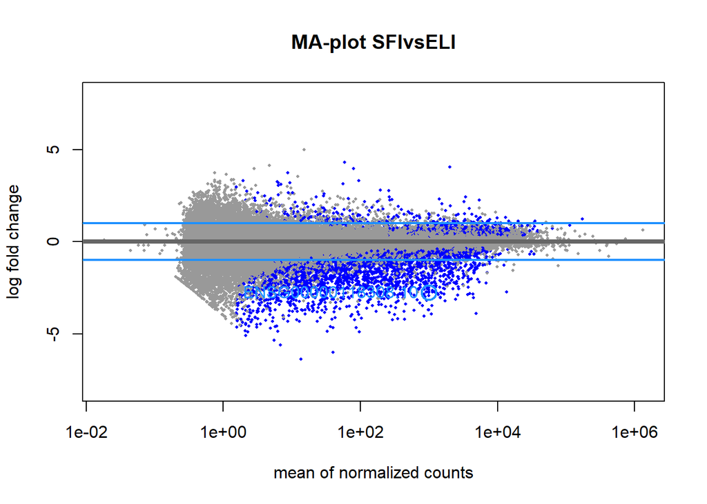

```r
DESeq2::plotMA(res_SFIvsELI, ylim = c(-8,8))
topGene3 <- rownames(res_SFIvsELI)[which.min(res_SFIvsELI$padj)]
with(res_SFIvsELI[topGene3, ], {
  points(baseMean, log2FoldChange, col = "dodgerblue", cex = 2, lwd = 2)
  text(baseMean, log2FoldChange, topGene3, pos = 2, col = "dodgerblue")
})
abline(h=c(-1,1), col="dodgerblue", lwd=2)
title("MA-plot SFIvsELI")
```

**Mirar si fer amb lfcShrink:**

## Histograma de los p-valores

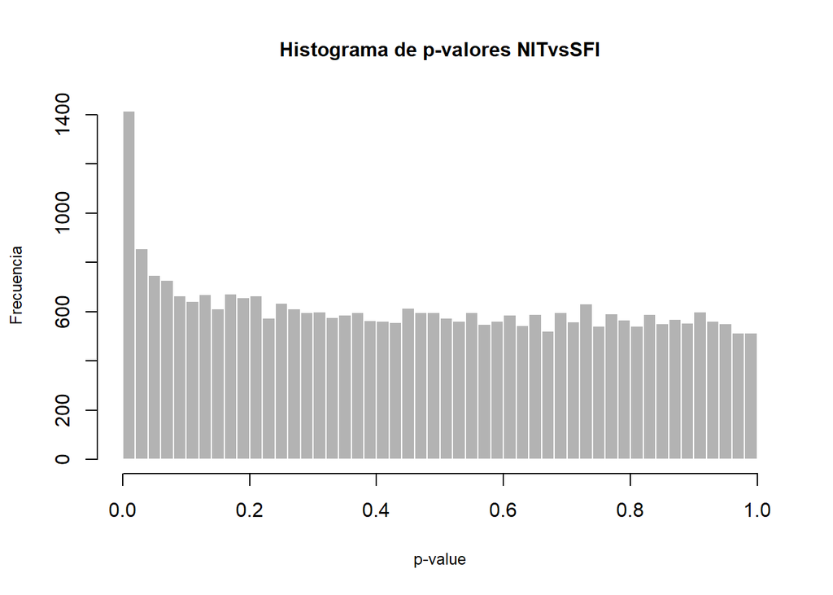

```r
hist(res_NITvsSFI$pvalue[res_NITvsSFI$baseMean > 1], breaks = 0:50/50, col = "grey70", border = "white", main = "Histograma de p-valores NITvsSFI", cex.main = 1, ylab = "Frecuencia", xlab = "p-value", cex.lab = 0.8)
```

Mirar teoria DESEQ2 from Michael I. Love.

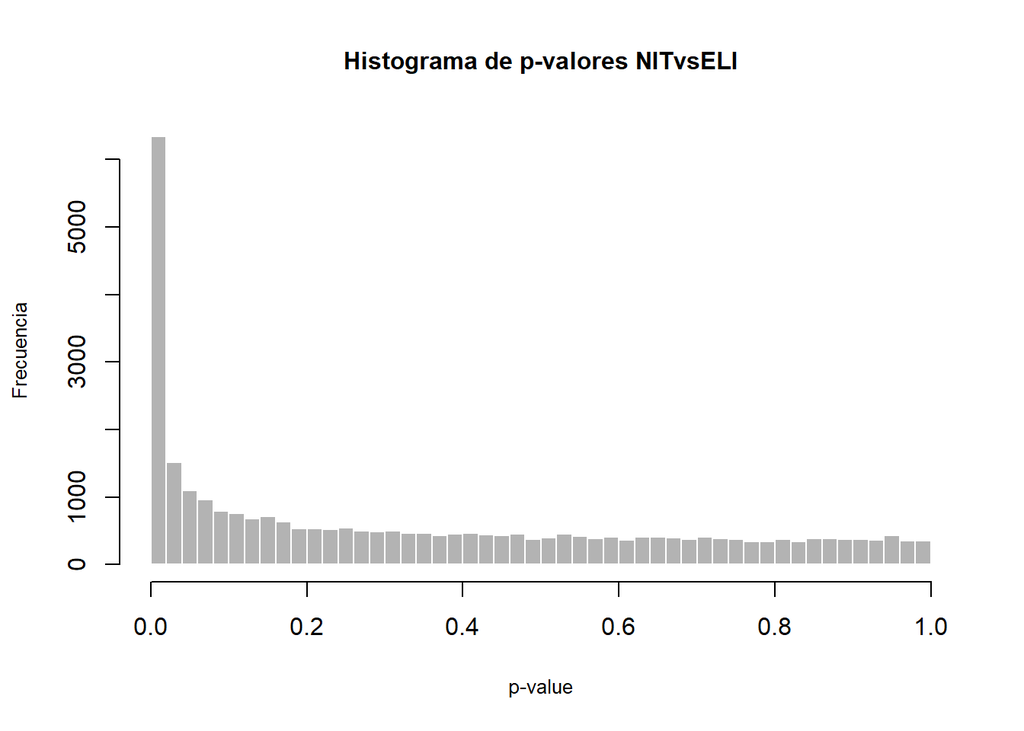

```r
hist(res_NITvsELI$pvalue[res_NITvsELI$baseMean > 1], breaks = 0:50/50, col = "grey70", border = "white", main = "Histograma de p-valores NITvsELI", cex.main = 1, ylab = "Frecuencia", xlab = "p-value", cex.lab = 0.8)
```

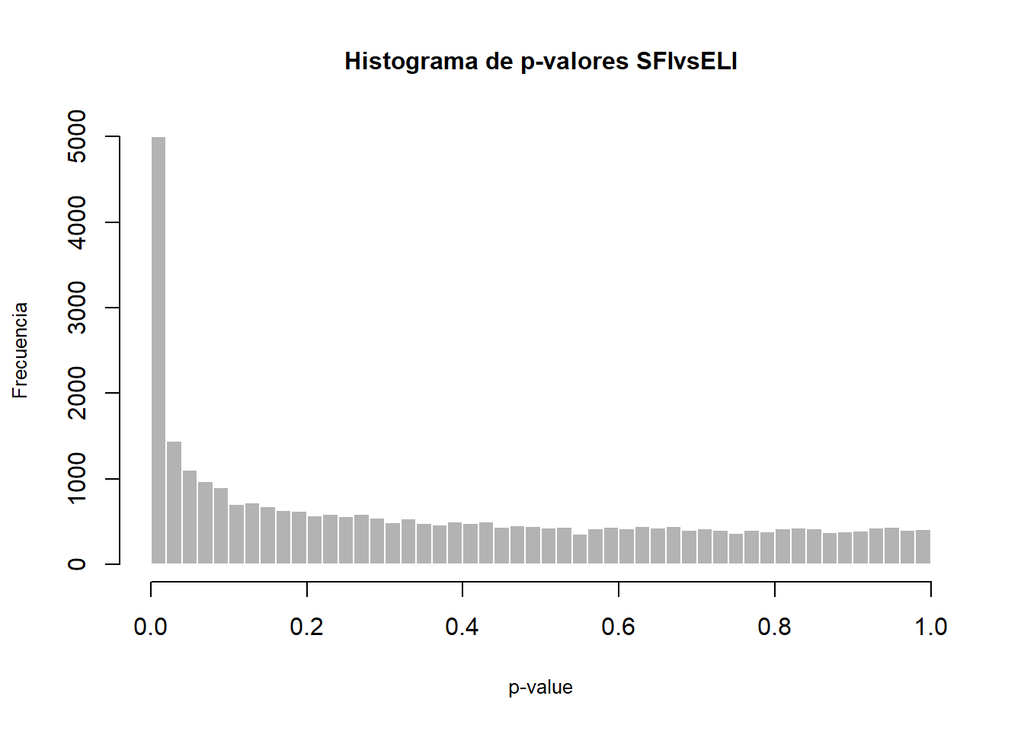

```r
hist(res_SFIvsELI$pvalue[res_SFIvsELI$baseMean > 1], breaks = 0:50/50, col = "grey70", border = "white", main = "Histograma de p-valores SFIvsELI", cex.main = 1, ylab = "Frecuencia", xlab = "p-value", cex.lab = 0.8)
```

## Dispersion plot and fitting alternatives

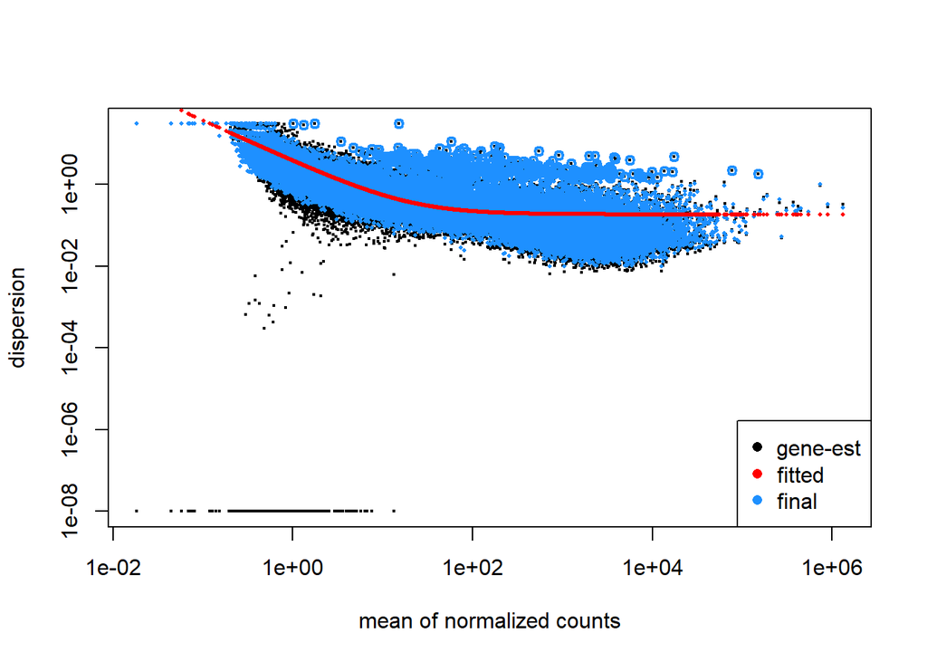

```r
plotDispEsts(dds)
```

## Gene clustering

```r
library("genefilter")
topVarGenes <- head(order(rowVars(assay(vsd)), decreasing = TRUE), 20)
topVarGenes
```

```
##  [1] 35151 24617 35801 35849 35828 24614 24618 35826 35846 24609  4539 33862
## [13] 33899 19750 24748  4517  4520  4524 24608 24603
```

```r
mat <- assay(vsd)[topVarGenes, ]
mat <- mat - rowMeans(mat)
anno <- as.data.frame(colData(vsd)["Group"])
pdf("pheatmap2.pdf")
pheatmap2 <- pheatmap(mat, annotation_col = anno)
dev.off()
```

## Independent filtering

Una de las debilidades de los datos RNAseq es que los genes poco expresados no es posible ver expresion diferencial, debido al ruido de fondo.

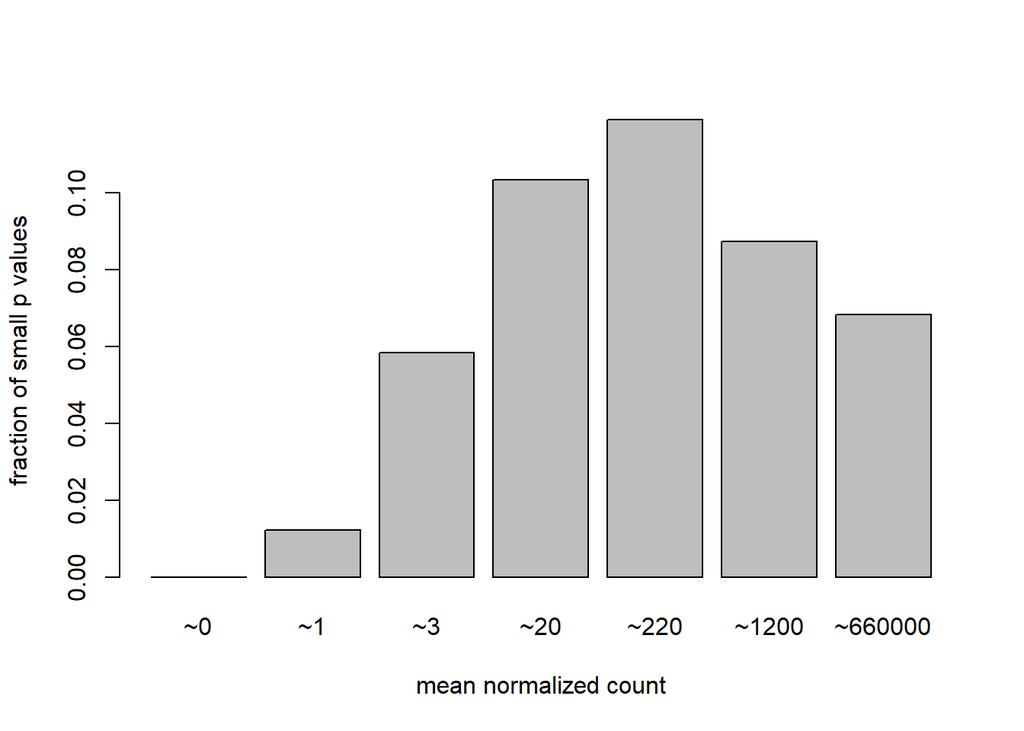

```r
qs <- c(0, quantile(res_NITvsSFI$baseMean[res_NITvsSFI$baseMean > 0], 0:6/6))
bins <- cut(res_NITvsSFI$baseMean, qs)
levels(bins) <- paste0("~", round(signif((qs[-1] + qs[-length(qs)])/2, 2)))
fractionSig <- tapply(res_NITvsSFI$pvalue, bins, function(p)
                          mean(p < .05, na.rm = TRUE))
barplot(fractionSig, xlab = "mean normalized count",
                     ylab = "fraction of small p values")
```

Este gráfico muestra que los genes con contajes muy bajos no tienen poder y estan excluidos del test. Estos genes tienen cierta influencia en el ajuste de testado múltiple, y su ejecución mejora cuando estos genes son excluidos.

## Comparación entre distintas comparaciones

```r
res_NITvsSFI.genes <- row.names(resSig_NITvsSFI)
res_NITvsELI.genes <- row.names(resSig_NITvsELI)
res_SFIvsELI.genes <- row.names(resSig_SFIvsELI)
```

```r
comb <- c(res_NITvsSFI.genes,res_NITvsELI.genes,res_SFIvsELI.genes)
```

```r
res_NITvsSFI.genes.2 <- comb %in% res_NITvsSFI.genes
res_NITvsELI.genes.2 <- comb %in% res_NITvsELI.genes
res_SFIvsELI.genes.2 <- comb %in% res_SFIvsELI.genes
```

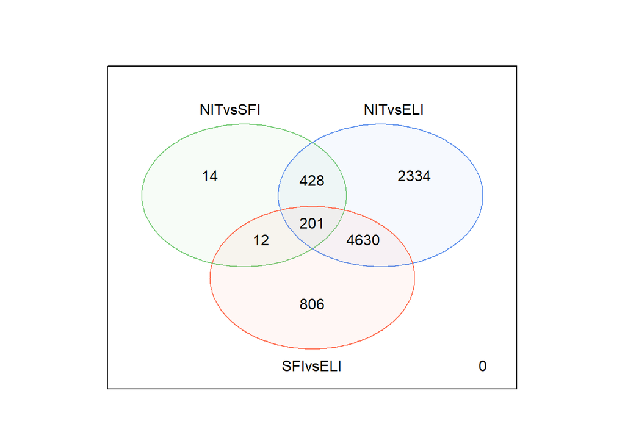

```r
venn_counts <- cbind(res_NITvsSFI.genes.2, res_NITvsELI.genes.2, res_SFIvsELI.genes.2)
venn_counts_results <- vennCounts(venn_counts)
vennDiagram(venn_counts_results, cex = 1, names=c("NITvsSFI","NITvsELI","SFIvsELI"), circle.col=c("palegreen3","cornflowerblue","coral1"))
```

# Anotación de los resultados

```r
BiocManager::install("AnnotationDbi")
BiocManager::install("org.Hs.eg.db")
library("AnnotationDbi")
library("org.Hs.eg.db")
columns(org.Hs.eg.db)
```

```
##  [1] "ACCNUM"       "ALIAS"        "ENSEMBL"      "ENSEMBLPROT"  "ENSEMBLTRANS"
##  [6] "ENTREZID"     "ENZYME"       "EVIDENCE"     "EVIDENCEALL"  "GENENAME"
## [11] "GO"           "GOALL"        "IPI"          "MAP"          "OMIM"
## [16] "ONTOLOGY"     "ONTOLOGYALL"  "PATH"         "PFAM"         "PMID"
## [21] "PROSITE"      "REFSEQ"       "SYMBOL"       "UCSCKG"       "UNIGENE"
## [26] "UNIPROT"
```

To remove the string after the period:

```r
row.names(res_NITvsSFI) <- gsub(x=row.names(res_NITvsSFI), pattern = "\\..*", replacement = "")
row.names(res_NITvsELI) <- gsub(x=row.names(res_NITvsELI), pattern = "\\..*", replacement = "")
row.names(res_SFIvsELI) <- gsub(x=row.names(res_SFIvsELI), pattern = "\\..*", replacement = "")
```

```r
res_NITvsSFI$symbol <- mapIds(org.Hs.eg.db, keys=row.names(res_NITvsSFI), column = "SYMBOL", keytype="ENSEMBL", multiVals = "first")
res_NITvsSFI$entrez <- mapIds(org.Hs.eg.db, keys=row.names(res_NITvsSFI), column = "ENTREZID", keytype="ENSEMBL", multiVals = "first")
res_NITvsSFI$genename <- mapIds(org.Hs.eg.db, keys=row.names(res_NITvsSFI), column = "GENENAME", keytype="ENSEMBL", multiVals = "first")
res_NITvsSFI_Ordered <- res_NITvsSFI[order(res_NITvsSFI$pvalue),]
res_NITvsSFI_Annot <- res_NITvsSFI_Ordered[which(res_NITvsSFI_Ordered$symbol != "NA"), ]
head(res_NITvsSFI_Annot)
```

```
## log2 fold change (MLE): Group NIT vs SFI
## Wald test p-value: Group NIT vs SFI
## DataFrame with 6 rows and 9 columns
##                  baseMean log2FoldChange     lfcSE      stat      pvalue
##                 <numeric>      <numeric> <numeric> <numeric>   <numeric>
## ENSG00000132465  7719.061       -5.14045  0.801605  -6.41270 1.42962e-10
## ENSG00000105369  1872.744       -5.28248  0.845055  -6.25104 4.07719e-10
## ENSG00000170476  1195.810       -4.86043  0.784789  -6.19329 5.89206e-10
## ENSG00000110777  2016.965       -4.59036  0.791125  -5.80232 6.54051e-09
## ENSG00000117322   871.678       -5.07437  0.952255  -5.32880 9.88654e-08
## ENSG00000143297  1677.871       -4.39256  0.830238  -5.29073 1.21832e-07
##                        padj      symbol      entrez
##                   <numeric> <character> <character>
## ENSG00000132465 9.84557e-08      JCHAIN        3512
## ENSG00000105369 2.55830e-07       CD79A         973
## ENSG00000170476 3.32737e-07        MZB1       51237
## ENSG00000110777 3.07796e-06     POU2AF1        5450
## ENSG00000117322 3.36333e-05         CR2        1380
## ENSG00000143297 3.95409e-05       FCRL5       83416
##                                                     genename
##                                                  <character>
## ENSG00000132465      joining chain of multimeric IgA and IgM
## ENSG00000105369                               CD79a molecule
## ENSG00000170476 marginal zone B and B1 cell specific protein
## ENSG00000110777    POU class 2 homeobox associating factor 1
## ENSG00000117322                    complement C3d receptor 2
## ENSG00000143297                           Fc receptor like 5
```

```r
res_NITvsELI$symbol <- mapIds(org.Hs.eg.db, keys=row.names(res_NITvsELI), column = "SYMBOL", keytype="ENSEMBL",  multiVals = "first")
res_NITvsELI$entrez <- mapIds(org.Hs.eg.db, keys=row.names(res_NITvsELI), column = "ENTREZID", keytype="ENSEMBL", multiVals = "first")
res_NITvsELI$genename <- mapIds(org.Hs.eg.db, keys=row.names(res_NITvsELI), column = "GENENAME", keytype="ENSEMBL", multiVals = "first")
res_NITvsELI_Ordered <- res_NITvsELI[order(res_NITvsELI$pvalue),]
res_NITvsELI_Annot <- res_NITvsELI_Ordered[which(res_NITvsELI_Ordered$symbol != "NA"), ]
head(res_NITvsELI_Annot)
```

```
## log2 fold change (MLE): Group NIT vs ELI
## Wald test p-value: Group NIT vs ELI
## DataFrame with 6 rows and 9 columns
##                  baseMean log2FoldChange     lfcSE      stat      pvalue
##                 <numeric>      <numeric> <numeric> <numeric>   <numeric>
## ENSG00000083454  1101.334       -6.31926  0.623398 -10.13680 3.79338e-24
## ENSG00000136573  1092.603       -6.79868  0.694097  -9.79501 1.18290e-22
## ENSG00000167483   809.646       -6.94637  0.709558  -9.78971 1.24649e-22
## ENSG00000156738  4902.360       -7.76238  0.808529  -9.60062 7.94686e-22
## ENSG00000035720   148.888       -6.48581  0.679336  -9.54727 1.33156e-21
## ENSG00000173200  1732.070       -4.59398  0.483754  -9.49652 2.17016e-21
##                        padj      symbol      entrez
##                   <numeric> <character> <character>
## ENSG00000083454 1.15027e-19       P2RX5        5026
## ENSG00000136573 1.25991e-18         BLK         640
## ENSG00000167483 1.25991e-18      NIBAN3      199786
## ENSG00000156738 6.02432e-18       MS4A1         931
## ENSG00000035720 7.86046e-18       STAP1       26228
## ENSG00000173200 9.40083e-18      PARP15      165631
##                                                       genename
##                                                    <character>
## ENSG00000083454                      purinergic receptor P2X 5
## ENSG00000136573 BLK proto-oncogene, Src family tyrosine kinase
## ENSG00000167483                    niban apoptosis regulator 3
## ENSG00000156738                 membrane spanning 4-domains A1
## ENSG00000035720     signal transducing adaptor family member 1
## ENSG00000173200   poly(ADP-ribose) polymerase family member 15
```

```r
res_SFIvsELI$symbol <- mapIds(org.Hs.eg.db, keys=row.names(res_SFIvsELI), column = "SYMBOL", keytype="ENSEMBL", multiVals = "first")
res_SFIvsELI$entrez <- mapIds(org.Hs.eg.db, keys=row.names(res_SFIvsELI), column = "ENTREZID", keytype="ENSEMBL", multiVals = "first")
res_SFIvsELI$genename <- mapIds(org.Hs.eg.db, keys=row.names(res_SFIvsELI), column = "GENENAME", keytype="ENSEMBL", multiVals = "first")
res_SFIvsELI_Ordered <- res_SFIvsELI[order(res_SFIvsELI$pvalue),]
res_SFIvsELI_Annot <- res_SFIvsELI_Ordered[which(res_SFIvsELI_Ordered$symbol != "NA"), ]
head(res_SFIvsELI_Annot)
```

```
## log2 fold change (MLE): Group SFI vs ELI
## Wald test p-value: Group SFI vs ELI
## DataFrame with 6 rows and 9 columns
##                  baseMean log2FoldChange     lfcSE      stat      pvalue
##                 <numeric>      <numeric> <numeric> <numeric>   <numeric>
## ENSG00000118308   984.664       -2.76216  0.360386  -7.66444 1.79612e-14
## ENSG00000069493  1084.588       -2.25105  0.308833  -7.28887 3.12568e-13
## ENSG00000074966   420.444       -3.02665  0.424304  -7.13323 9.80417e-13
## ENSG00000196172   220.306       -1.16607  0.167624  -6.95644 3.48973e-12
## ENSG00000111913  1434.234       -2.47621  0.356321  -6.94938 3.66890e-12
## ENSG00000068831  3683.217       -2.87925  0.415866  -6.92352 4.40562e-12
##                        padj      symbol      entrez
##                   <numeric> <character> <character>
## ENSG00000118308 5.19634e-10        LRMP        4033
## ENSG00000069493 4.52145e-09      CLEC2D       29121
## ENSG00000074966 9.45481e-09         TXK        7294
## ENSG00000196172 2.02652e-08      ZNF681      148213
## ENSG00000111913 2.02652e-08      RIPOR2        9750
## ENSG00000068831 2.02652e-08     RASGRP2       10235
##                                                             genename
##                                                          <character>
## ENSG00000118308                 lymphoid restricted membrane protein
## ENSG00000069493               C-type lectin domain family 2 member D
## ENSG00000074966                                  TXK tyrosine kinase
## ENSG00000196172                              zinc finger protein 681
## ENSG00000111913 RHO family interacting cell polarization regulator 2
## ENSG00000068831                       RAS guanyl releasing protein 2
```

```r
write.xlsx(res_SFIvsELI_Annot, "./Resultados/res_SFIvsELI_Annot.xlsx")
```

## Volcano plots:

```r
genesymbols1 <- res_NITvsSFI_Annot$symbol
pdf("volcano_NITvsSFI.pdf")
volcano_NITvsSFI <- plot(res_NITvsSFI_Annot$log2FoldChange, -log10(res_NITvsSFI_Annot$padj), panel.first = grid(), main = "Volcano plot NITvsSFI", xlab="Effect size: log2 Fold-change", ylab="-log10(adj p-value)", pch=20, cex=0.6)
abline(v=0)
abline(v=c(-1,1), col="dodgerblue")
abline(h=-log10(0.05), col="dodgerblue")
gn.selected <- abs(res_NITvsSFI_Annot$log2FoldChange) > 2.5 & res_NITvsSFI_Annot$padj < 0.05
text(res_NITvsSFI_Annot$log2FoldChange[gn.selected],
     -log10(res_NITvsSFI_Annot$padj)[gn.selected],
     lab=genesymbols1[gn.selected], cex=0.4)
dev.off()
```

```r
genesymbols2 <- res_NITvsELI_Annot$symbol
pdf("volcano_NITvsELI.pdf")
volano_NITvsELI <- plot(res_NITvsELI_Annot$log2FoldChange, -log10(res_NITvsELI_Annot$padj), panel.first = grid(), main = "Volcano plot NITvsELI", xlab="Effect size: log2 Fold-change", ylab="-log10(adj p-value)", pch=20, cex=0.6)
abline(v=0)
abline(v=c(-1,1), col="dodgerblue")
abline(h=-log10(0.05), col="dodgerblue")
gn.selected <- abs(res_NITvsELI_Annot$log2FoldChange) > 4 & res_NITvsELI_Annot$padj < 0.05
text(res_NITvsELI_Annot$log2FoldChange[gn.selected],
     -log10(res_NITvsELI_Annot$padj)[gn.selected],
     lab=genesymbols2[gn.selected], cex=0.4)
dev.off()
```

```r
genesymbols3 <- res_SFIvsELI_Annot$symbol
pdf("volcano_SFIvsELI.pdf")
volcano_SFIvsELI <- plot(res_SFIvsELI_Annot$log2FoldChange, -log10(res_SFIvsELI_Annot$padj), panel.first = grid(), main = "Volcano plot SFIvsELI", xlab="Effect size: log2 Fold-change", ylab="-log10(adj p-value)", pch=20, cex=0.6)
abline(v=0)
abline(v=c(-1,1), col="dodgerblue")
abline(h=-log10(0.05), col="dodgerblue")
gn.selected <- abs(res_SFIvsELI_Annot$log2FoldChange) > 4 & res_SFIvsELI_Annot$padj < 0.05
text(res_SFIvsELI_Annot$log2FoldChange[gn.selected],
     -log10(res_SFIvsELI_Annot$padj)[gn.selected],
     lab=genesymbols3[gn.selected], cex=0.4)
dev.off()
```

# Análisis de significación biológica

```r
BiocManager::install("clusterProfiler")
BiocManager::install("xlsx")
library(clusterProfiler)
GO_NITvsSFI <- as.data.frame(res_NITvsSFI_Annot)
head(GO_NITvsSFI)
```

```
##                  baseMean log2FoldChange     lfcSE      stat       pvalue
## ENSG00000132465 7719.0610      -5.140455 0.8016050 -6.412703 1.429622e-10
## ENSG00000105369 1872.7436      -5.282475 0.8450550 -6.251044 4.077190e-10
## ENSG00000170476 1195.8098      -4.860429 0.7847893 -6.193291 5.892063e-10
## ENSG00000110777 2016.9654      -4.590357 0.7911249 -5.802316 6.540506e-09
## ENSG00000117322  871.6781      -5.074373 0.9522549 -5.328797 9.886536e-08
## ENSG00000143297 1677.8711      -4.392559 0.8302376 -5.290725 1.218322e-07
##                         padj  symbol entrez
## ENSG00000132465 9.845565e-08  JCHAIN   3512
## ENSG00000105369 2.558301e-07   CD79A    973
## ENSG00000170476 3.327366e-07    MZB1  51237
## ENSG00000110777 3.077962e-06 POU2AF1   5450
## ENSG00000117322 3.363328e-05     CR2   1380
## ENSG00000143297 3.954086e-05   FCRL5  83416
##                                                     genename
## ENSG00000132465      joining chain of multimeric IgA and IgM
## ENSG00000105369                               CD79a molecule
## ENSG00000170476 marginal zone B and B1 cell specific protein
## ENSG00000110777    POU class 2 homeobox associating factor 1
## ENSG00000117322                    complement C3d receptor 2
## ENSG00000143297                           Fc receptor like 5
```

```r
GO_NITvsELI <- as.data.frame(res_NITvsELI_Annot)
head(GO_NITvsELI)
```

```
##                  baseMean log2FoldChange     lfcSE       stat       pvalue
## ENSG00000083454 1101.3342      -6.319262 0.6233983 -10.136796 3.793380e-24
## ENSG00000136573 1092.6033      -6.798680 0.6940966  -9.795007 1.182897e-22
## ENSG00000167483  809.6461      -6.946372 0.7095583  -9.789713 1.246489e-22
## ENSG00000156738 4902.3599      -7.762379 0.8085294  -9.600615 7.946862e-22
## ENSG00000035720  148.8879      -6.485810 0.6793364  -9.547273 1.331556e-21
## ENSG00000173200 1732.0704      -4.593980 0.4837539  -9.496523 2.170161e-21
##                         padj symbol entrez
## ENSG00000083454 1.150267e-19  P2RX5   5026
## ENSG00000136573 1.259910e-18    BLK    640
## ENSG00000167483 1.259910e-18 NIBAN3 199786
## ENSG00000156738 6.024317e-18  MS4A1    931
## ENSG00000035720 7.860456e-18  STAP1  26228
## ENSG00000173200 9.400827e-18 PARP15 165631
##                                                       genename
## ENSG00000083454                      purinergic receptor P2X 5
## ENSG00000136573 BLK proto-oncogene, Src family tyrosine kinase
## ENSG00000167483                    niban apoptosis regulator 3
## ENSG00000156738                 membrane spanning 4-domains A1
## ENSG00000035720     signal transducing adaptor family member 1
## ENSG00000173200   poly(ADP-ribose) polymerase family member 15
```

```r
GO_SFIvsELI <- as.data.frame(res_SFIvsELI_Annot)
head(GO_SFIvsELI)
```

```
##                  baseMean log2FoldChange     lfcSE      stat       pvalue
## ENSG00000118308  984.6640      -2.762156 0.3603859 -7.664441 1.796116e-14
## ENSG00000069493 1084.5876      -2.251046 0.3088334 -7.288869 3.125681e-13
## ENSG00000074966  420.4444      -3.026654 0.4243036 -7.133228 9.804170e-13
## ENSG00000196172  220.3064      -1.166066 0.1676239 -6.956442 3.489729e-12
## ENSG00000111913 1434.2339      -2.476210 0.3563209 -6.949382 3.668903e-12
## ENSG00000068831 3683.2166      -2.879255 0.4158658 -6.923518 4.405620e-12
##                         padj  symbol entrez
## ENSG00000118308 5.196342e-10    LRMP   4033
## ENSG00000069493 4.521455e-09  CLEC2D  29121
## ENSG00000074966 9.454815e-09     TXK   7294
## ENSG00000196172 2.026521e-08  ZNF681 148213
## ENSG00000111913 2.026521e-08  RIPOR2   9750
## ENSG00000068831 2.026521e-08 RASGRP2  10235
##                                                             genename
## ENSG00000118308                 lymphoid restricted membrane protein
## ENSG00000069493               C-type lectin domain family 2 member D
## ENSG00000074966                                  TXK tyrosine kinase
## ENSG00000196172                              zinc finger protein 681
## ENSG00000111913 RHO family interacting cell polarization regulator 2
## ENSG00000068831                       RAS guanyl releasing protein 2
```

```r
library("dplyr")
library("xlsx")
universe_prova <- list(NITvsSFI = GO_NITvsSFI$entrez, NITvsELI = GO_NITvsELI$entrez, SFIvsELI = GO_SFIvsELI$entrez)
func <- function(x) {
  x %>% filter(padj < 0.05, !is.na(entrez)) %>% pull(entrez)
}
sigGenes_prova <- list(NITvsSFI = GO_NITvsSFI, NITvsELI = GO_NITvsELI, SFIvsELI = GO_SFIvsELI) %>% lapply(func)
comparisonsNames <- names(sigGenes_prova)

for (i in 1:length(sigGenes_prova)){
  genesIn <- sigGenes_prova[[i]]
  comparison <- comparisonsNames[i]
  enrich.result <- enrichGO(gene = genesIn, OrgDb = org.Hs.eg.db, ont = "ALL", pAdjustMethod = "BH", pvalueCutoff = 0.05, universe = universe_prova, readable = TRUE)

cat("##################################")
 cat("\nComparison: ", comparison,"\n")
 print(head(enrich.result))

if (length(rownames(enrich.result@result)) != 0) {
 write.csv(as.data.frame(enrich.result),
            file =paste0("./Resultados/","Enrich.Results.",comparison,".csv"),
            row.names = FALSE)

write.xlsx(as.data.frame(enrich.result),
            file =paste0("./Resultados/","Enrich.Results.",comparison,".xlsx"),
            row.names = FALSE)

 pdf(file=paste0("./Resultados/","Enrich.Dotplot.",comparison,".pdf"))
   print(dotplot(enrich.result, showCategory = 15, font.size = 6,
           title = paste0("EnrichGO Pathway Analysis for ", comparison,". Dotplot")))
 dev.off()

 pdf(file = paste0("./Resultados/","EnrichGOemapplot.",comparison,".pdf"))
   print(emapplot(enrich.result, categorySize = "geneNum", schowCategory = 15,
        vertex.label.cex = 0.75))
 dev.off()

 }
}
```

```
## ##################################
## Comparison:  NITvsSFI
##            ONTOLOGY         ID                                 Description
## GO:0030098       BP GO:0030098                  lymphocyte differentiation
## GO:0042113       BP GO:0042113                           B cell activation
## GO:0042100       BP GO:0042100                        B cell proliferation
## GO:0050853       BP GO:0050853           B cell receptor signaling pathway
## GO:0070661       BP GO:0070661                     leukocyte proliferation
## GO:0050851       BP GO:0050851 antigen receptor-mediated signaling pathway
##            GeneRatio   BgRatio       pvalue     p.adjust       qvalue
## GO:0030098     16/83 353/18670 3.117187e-12 4.809819e-09 4.012968e-09
## GO:0042113     15/83 310/18670 6.316444e-12 4.873137e-09 4.065796e-09
## GO:0042100     10/83  95/18670 1.283210e-11 6.599978e-09 5.506548e-09
## GO:0050853     10/83 129/18670 2.765868e-10 1.066934e-07 8.901729e-08
## GO:0070661     13/83 298/18670 6.545921e-10 2.020071e-07 1.685402e-07
## GO:0050851     13/83 316/18670 1.337265e-09 3.439000e-07 2.869255e-07
##                                                                                                 geneID
## GO:0030098      CD79A/CR2/MS4A1/LEPR/IRF4/FCRL3/CD19/LY9/IHH/TNFRSF18/ITK/RUNX3/CD28/PTPRC/EOMES/IKZF3
## GO:0042113 CD79A/MZB1/CR2/TNFRSF13B/MS4A1/IGLL5/FCRL3/CD19/FCRL1/SLA2/CXCR5/TNFRSF13C/CD28/PTPRC/IKZF3
## GO:0042100                             CD79A/MZB1/CR2/TNFRSF13B/MS4A1/FCRL3/CD19/TNFRSF13C/PTPRC/IKZF3
## GO:0050853                                       CD79A/MS4A1/IGLL5/FCRL3/CD19/STAP1/BLK/PAX5/ITK/PTPRC
## GO:0070661              CD79A/MZB1/CR2/TNFRSF13B/MS4A1/FCRL3/CD19/IL5RA/IHH/TNFRSF13C/CD28/PTPRC/IKZF3
## GO:0050851                       CD79A/MS4A1/IGLL5/FCRL3/CD19/STAP1/BLK/TRAT1/SLA2/PAX5/ITK/CD28/PTPRC
##            Count
## GO:0030098    16
## GO:0042113    15
## GO:0042100    10
## GO:0050853    10
## GO:0070661    13
## GO:0050851    13
```

[output not shown]

[output not shown]

```r
BiocManager::install("clusterProfiler")
```